# CogLab Data Presentation

Metacontrast Masking

Jamie Daniels & Shannon McCarthy

February 14, 2019

# Intro

# Background

- Visual perception is a process that can be interupted or blocked by the introduction of a mask.
  - A mask is a brief stimuli that disrupts the perception of the target stimuli.
- The purpose of this experiment is to have participants focus on the fixation point at the center of the screen and determine the position of the target stimuli (a retangle).
- Three other squares will appear around the fixation point in addition to the rectangle
- Each trial will have a box drawn around the four stimuli
- The time between the presentation of the stimuli and the box drawn will vary between trials -Subjects indicate the location of the rectangle (top left, top right, bottom left, or bottom right)

# Methods

**Variables of Interest**

| Independent Variables | Dependent Variable | Constant |
| --- | --- | --- |
| Stimulus onset asynchrony | Proportion of correct resposes | Fixation point |
| Horizontal object position |  |  |
| Vertical object position |  |  |

**Participants**

- 77 undergraduate students ages (17-25)
- Males and Females
- The students participated in this lab as part of the labratory in sensory processing class.

# Methods

**Equipment**

- Web Browser
- Computer or Tablet
- LCD screen
- Working internet connection
- keyboard/mouse (touchscreen capability if tablet)

# Methods

**Procedures**

# Data Wrangling

```r
library("tidyverse")
library("forcats")

data_file <-"mmask_all.csv"

data_set <- read_csv(ifelse(!file.exists(data_file),
                            paste("./CogLab_reports/coglab_pres/",
                                  data_file,sep="/"),data_file))
```

```r
mask_acc<-data_set %>%
  group_by(randomGator,SOA) %>%
  count(Accuracy) %>%
  mutate(prop = prop.table(n)) # Filled in missing conmbinations of Accuracy, Target, SOA
```

```r
maska <- mask_acc %>%
  group_by(randomGator) %>%
  complete(Accuracy, SOA, fill = list(n = 0,prop = 0))

maska_grp <- maska %>%
  group_by(Accuracy, SOA) %>%
  summarise(sd=sd(prop),avg=mean(prop),ymin=avg-sd,ymax=avg+sd)
```

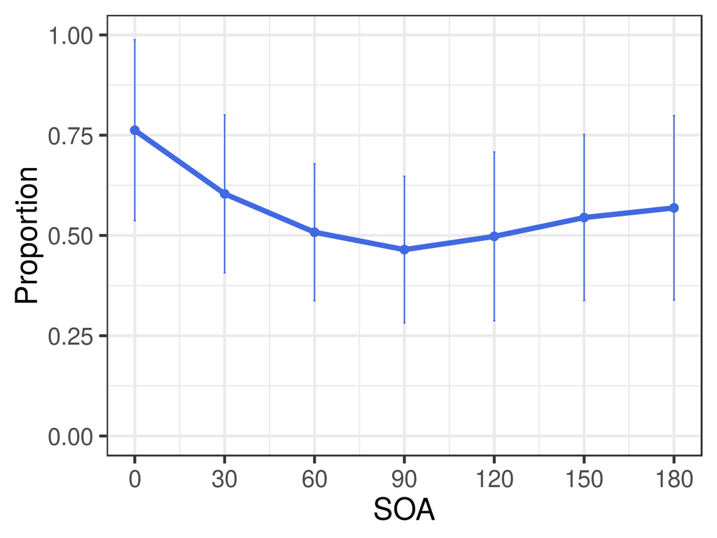

```r
ggplot(maska_grp %>% filter(Accuracy== 1),aes(x=SOA, y=avg, group= Accuracy)) +
  geom_line(size=2,color="royalblue") +
  geom_point(size = 3,color="royalblue") +
  geom_errorbar(aes(y=avg,ymin = ymin, ymax = ymax),width=0.7,color="royalblue")+
  scale_x_continuous(breaks = c(0,30,60,90,120,150,180))+
  scale_y_continuous("Proportion",breaks = c(-0.25,0.0,0.25,0.50,0.75,1.0)) +
  theme_bw(24)+coord_cartesian(ylim=c(0,1))
```